# A6_Duong_Tram

TramooD17

01/03/2022

INTRODUCTORY An unknown sequence has been found in a patient.

Github Repository Link: https://github.com/TramooD17/DNA-Alignments

Setting Up needed libraries and packages:

```r
library(BiocManager)
library(annotate)
library(genbankr)
library(ape)
library(muscle)
library(dplyr)
library(Biostrings)
library(reshape2)
library(ggtree)
```

Sequence of Interest: > Human isolate, unknown sequence ATGTCTGATAATGGACCCCAAAATCAGCGAAATGCACCCCGCATTACGTTTGGTGGACCC…

ANALYSIS The sequence was converted into a character object:

```r
unkown <- "ATGTCTGATAATGGACCCCAAAATCAGCGAAATGCACCCCGCATTACGTTTGGTGGACCC…"
```

BLAST was used to find sequences similar to the unknown sequence:

```r
unkownBLAST <- blastSequences(paste(unkown), as='data.frame',hitListSize = 40, timeout = 600)
```

```
## estimated response time 21 seconds
```

```
## elapsed time 21 seconds
```

```
## elapsed time 32 seconds
```

A vector of accession numbers from the BLAST results was made and turned into a dataframe:

```r
unkownhitsdf <- data.frame(ID=unkownBLAST$Hit_accession,Seq=unkownBLAST$Hsp_hseq,stringsAsFactors = FALSE)
```

Sequences were read from GenBank:

```r
unknownseqs <- read.GenBank(unkownBLAST$Hit_accession[1:3])
```

The species that matched closest to the sequence of interest found in the patient is severe acute respiratory syndrome corona virus 2 (SARS-Cov2), according to the top three BLAST results.

```r
attr(unknownseqs,"species")
```

```
## [1] "Severe_acute_respiratory_syndrome_coronavirus_2"
## [2] "Severe_acute_respiratory_syndrome_coronavirus_2"
## [3] "Severe_acute_respiratory_syndrome_coronavirus_2"
```

```r
unknownDNAString <- unkownhitsdf$Seq %>%
  as.character %>%
  lapply(.,paste0,collapse="") %>%
  unlist %>%
  DNAStringSet
```

Each sequence was given a unique name for organizational purposes, using index numbers:

```r
names(unknownDNAString) <- paste(1:nrow(unkownhitsdf),unkownhitsdf$ID,sep="_")
```

The sequences were aligned:

```r
unknownalign <- muscle::muscle(stringset = unknownDNAString, quiet = T)
```

The alignment was inspected for large gaps in the sequences:

```r
detail(unknownalign)
```

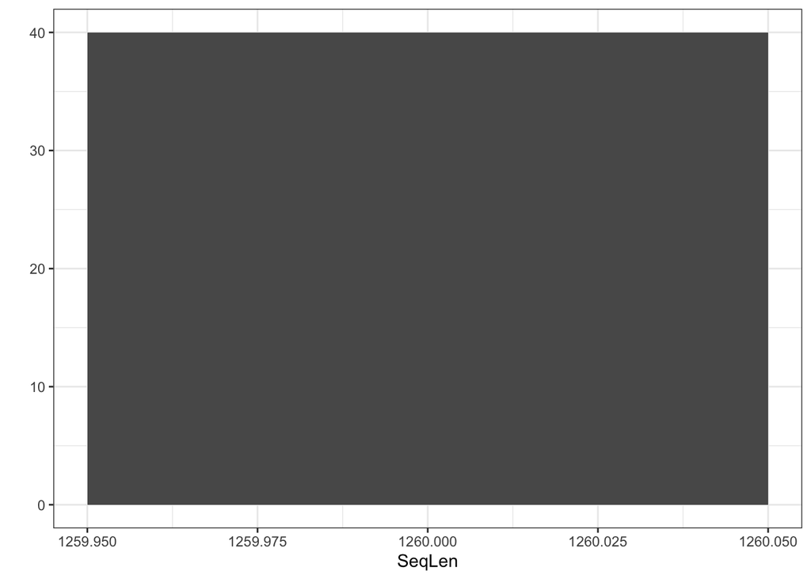

```r
SeqLen <- as.numeric(lapply(unknownDNAString,length))
library(ggplot2)
qplot(SeqLen)+theme_bw()
```

Figure 1. Histogram depicting sequence length of the sequences collected from BLAST. There appear to be no gaps in the sequence.

A distance matrix was created in order to prepare a phylogenetic tree. The DNAMultipleAlignment object was first converted into a DNABin and rearranged into a linear matrix:

```r
unknownalignBin <- as.DNAbin(unknownalign)
unDM <- dist.dna(unknownalignBin, model = "K80")
unDMmat <- as.matrix(unDM)
uDat <- melt(unDMmat)
dim(uDat)
```

```
## [1] 1600    3
```

The matrix was visualized:

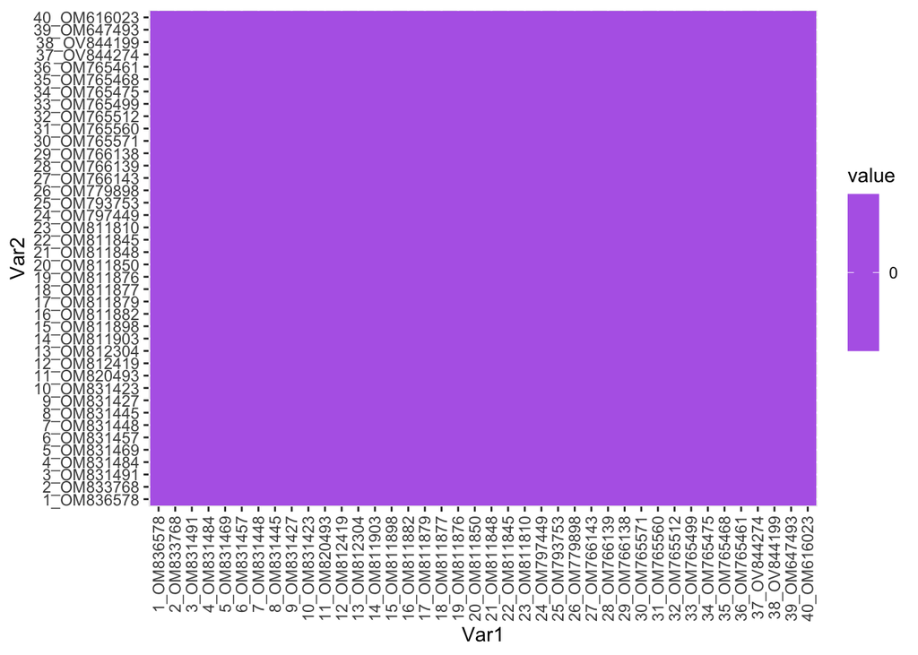

```r
ggplot(data = uDat, aes(x=Var1, y=Var2, fill=value)) +
  geom_tile()+scale_fill_gradientn(colours=c("white","blue","pink","yellow")) +
  theme(axis.text.x = element_text(angle = 90, hjust = 1, vjust = 0.5))
```

Figure 2. A matrix was generated to visualize alignments in the aligned sequences. It appears that all sequences are identical to each other.

Using the distance matrix, a Neighbour-Joining phylogenetic tree was created for the aligned sequences:

```r
untree <- nj(unDM)
```

[figure not shown]

```r
ggtree(untree)
```

The tree file was saved:

```r
write.tree(untree,"A6_Duong_Tram.tre")
```